# Aula 6 - Econometria de Séries Temporais

João Ricardo F. de Lima

23 de março de 2022.

# 1 Metodologia de Box-Jenkins

Nos anos 70, Box e Jenkins utilizam da análise de “correlogramas” para identificar se uma série era I(0) ou não e para identificar as ordens “p” e “q” do modelo. Posteriormente, foram definidos testes estatísticos com tal finalidade, denominados de testes de raiz unitária, já vistos. Segundo a metodologia de Box-Jenkins, a análise de séries temporais tem por objetivo principal a realização de previsões.

Esta metodologia permite fazer previsões com base nos valores contemporâneos e passados explorando a correlação temporal entre os valores realizados pela série. O primeiro passo da metodologia é a *Identificação*. Isto significa descobrir qual dos possíveis modelos ARIMA descreve o comportamento da série. Filosofia: “Deixem os dados falarem por si mesmos”. Em outras palavras, é identificar os valores de “p”, “d” e “q”. Isto não pode ser feito apenas com a observação visual da série.

O primeiro passo na identificação é avaliar se a série é estacionária. Se não for, a série deve ser diferenciada “d” vezes até se tornar estacionária. Sendo a série original ou diferenciada, estacionária, o próximo passo é determinar se é gerada por um termo AR(p), MA(q) ou ARMA(p,q), além dos próprios valores de “p” e “q”.

De forma resumida e simplificada, o comportamento da FAC e FACp pode ser dado por:

Tabela 1: Comportamento da FAC e FACp:

| Processo | FAC | FACP |
| --- | --- | --- |
| AR(p) | Declinante | Truncada k=p |
| MA(q) | Truncada k=p | Declinante |
| ARMA(p,q) | Declinante | Declinante |

A **identificação** é a mais difícil das etapas da metodologia de Box e Jenkins. Normalmente mais de um modelo é escolhido para testar se é o gerador da série. Uma possibilidade é escolher o modelo com base nos critérios de Akaike (AIC) e Schwarz (BIC).

A segunda etapa é a **estimação** do modelo, sempre considerando o princípio da parcimônia.

A terceira etapa é a **verificação**: verificar se o modelo é adequado. A forma mais comum é a análise dos resíduos. Na análise dos resíduos deve-se verificar se o comportamento é de um ruído branco. Para isto, pode-se fazer um correlograma dos resíduos.

A quarta etapa é a **previsão**.

## 1.1 Estimação no R - Metodologia de Box-Jenkins

```r
#Direcionado o R para o Diretorio a ser trabalhado
setwd('C:/Users/Joao Ricardo Lima/Dropbox/tempecon/facape/econometria2')

#Inicio do Script

#Pacotes a serem usados
library(forecast)
library(ggplot2)
library(urca)
library(tseries)
library(lmtest)
library(readxl)
library(tidyverse)
library(kableExtra)

options(digits=4)

divida <- read_excel("Divggnp_19032022.xls", col_types = 'numeric', sheet = "% PIB")

# Tratar DADOS #
divida <- t(divida[-c(1:8, 58:73),-c(1)])
divida <- ts(divida, start=c(2006,12), freq=12)

# Rotular
colnames(divida) <- c(1:49)

dbgg <- divida[,c(3)] #divida bruta do governo geral

date <- seq(as.Date('2006-12-01'),to=as.Date("2022-01-01"),by='1 month')
dbgg2 <- tibble(date,dbgg)
```

## 1.2 Gráfico da série, FAC e FACp

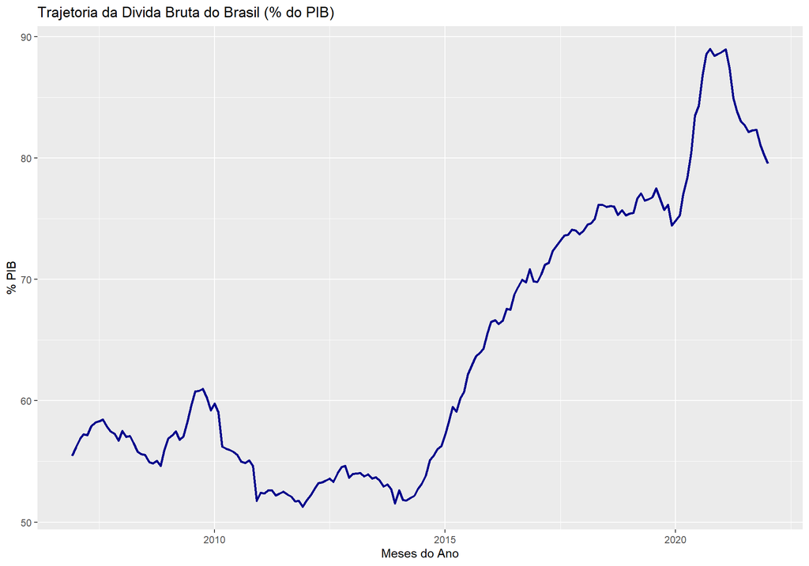

```r
# Grafico da Serie
#Gráfico
ggplot(data=dbgg2) +
  geom_line(aes(x=date, y=dbgg), colour="darkblue", size=1.0) +
  xlab('Meses do Ano') + ylab('% PIB') +
  ggtitle('Trajetoria da Divida Bruta do Brasil (% do PIB)')
```

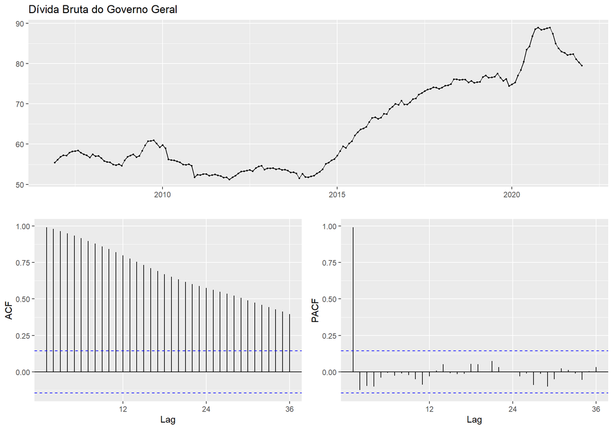

```r
##Correlograma das series
#Visualizando as duas funcoes - FAC e FACP

ggtsdisplay(dbgg, main='Dívida Bruta do Governo Geral')
```

Os Correlogramas da série em nível, mostrado abaixo, indicam que a mesma não deve ser estacionária.

## 1.3 Teste de Raiz Unitária

```r
##Correlograma das series
#Visualizando as duas funcoes - FAC e FACP

#Analise dos testes de raiz unitaria em nivel
#Definicao do numero maximo de lags
print(12*(length(dbgg)/100)^(1/4))
```

```
# [1] 13.94
```

```r
#Estatistica de Teste DFGLS para DCP
dbgg.dfgls <- ur.ers(dbgg, type = c("DF-GLS"),
                     model = c("trend"),
                     lag.max = 2)
summary(dbgg.dfgls)
```

```
#
# ###############################################
# # Elliot, Rothenberg and Stock Unit Root Test #
# ###############################################
#
# Test of type DF-GLS
# detrending of series with intercept and trend
#
#
# Call:
# lm(formula = dfgls.form, data = data.dfgls)
#
# Residuals:
#     Min      1Q  Median      3Q     Max
# -2.9186 -0.4581  0.0136  0.3489  2.1595
#
# Coefficients:
#              Estimate Std. Error t value Pr(>|t|)
# yd.lag       -0.01204    0.00807   -1.49   0.1375
# yd.diff.lag1  0.30604    0.07350    4.16  4.9e-05 ***
# yd.diff.lag2  0.20727    0.07401    2.80   0.0057 **
# ---
# Signif. codes:  0 '***' 0.001 '**' 0.01 '*' 0.05 '.' 0.1 ' ' 1
#
# Residual standard error: 0.718 on 176 degrees of freedom
# Multiple R-squared:  0.185,   Adjusted R-squared:  0.171
# F-statistic: 13.3 on 3 and 176 DF,  p-value: 6.99e-08
#
#
# Value of test-statistic is: -1.492
#
# Critical values of DF-GLS are:
#                  1pct  5pct 10pct
# critical values -3.46 -2.93 -2.64
```

O teste de raiz unitária DF-GLS da série em nível, leva a seguinte conclusão de que a série não é estacionária em nível.

## 1.4 Análise da série na 1 Diferença

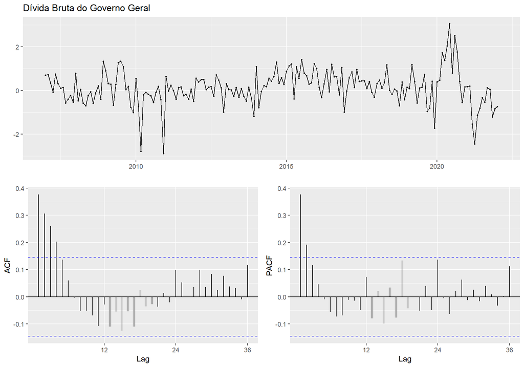

```r
#Diferenciacao da Serie
ddbgg <- diff(dbgg)

##Correlograma das series na 1 Diferença
#Visualizando as duas funcoes - FAC e FACP

ggtsdisplay(ddbgg, main='Dívida Bruta do Governo Geral')
```

```r
# Teste de Raiz Unitária

ddbgg.dfgls <- ur.ers(ddbgg, type = c("DF-GLS"),
                      model = c("constant"),
                      lag.max = 2)
summary(ddbgg.dfgls)
```

```
#
# ###############################################
# # Elliot, Rothenberg and Stock Unit Root Test #
# ###############################################
#
# Test of type DF-GLS
# detrending of series with intercept
#
#
# Call:
# lm(formula = dfgls.form, data = data.dfgls)
#
# Residuals:
#     Min      1Q  Median      3Q     Max
# -2.9175 -0.5047 -0.0914  0.2894  1.6566
#
# Coefficients:
#              Estimate Std. Error t value Pr(>|t|)
# yd.lag        -0.2893     0.0778   -3.72  0.00027 ***
# yd.diff.lag1  -0.3786     0.0871   -4.35  2.4e-05 ***
# yd.diff.lag2  -0.1729     0.0754   -2.29  0.02299 *
# ---
# Signif. codes:  0 '***' 0.001 '**' 0.01 '*' 0.05 '.' 0.1 ' ' 1
#
# Residual standard error: 0.736 on 175 degrees of freedom
# Multiple R-squared:  0.316,   Adjusted R-squared:  0.305
# F-statistic:   27 on 3 and 175 DF,  p-value: 2.12e-14
#
#
# Value of test-statistic is: -3.72
#
# Critical values of DF-GLS are:
#                  1pct  5pct 10pct
# critical values -2.58 -1.94 -1.62
```

Os Correlogramas da série na primeira diferença, mostrado abaixo, indicam que a mesma pode ser estacionária. O teste de raiz unitária DF-GLS com a variável dbgg na primeira diferença leva a conclusão de que considerando uma significância de 10%, rejeita a Hipótese Nula de que a série possui raiz unitária, ou seja, a série é estacionária.

Existem duas formas de estimação, uma delas é observando o correlograma e a outra é usando a função `auto.arima`.

## 1.5 Estimacao do Modelo ARIMA usando a função auto.arima

```r
auto.arima <- auto.arima(dbgg, max.p=10, max.d=1, max.q=10, trace=TRUE)
```

```
#
#  Fitting models using approximations to speed things up...
#
#  ARIMA(2,1,2)(1,0,1)[12] with drift         : 402.4
#  ARIMA(0,1,0)            with drift         : 431.5
#  ARIMA(1,1,0)(1,0,0)[12] with drift         : 415.3
#  ARIMA(0,1,1)(0,0,1)[12] with drift         : 416
#  ARIMA(0,1,0)                               : 434.5
#  ARIMA(2,1,2)(0,0,1)[12] with drift         : 401.6
#  ARIMA(2,1,2)            with drift         : 401.6
#  ARIMA(2,1,2)(1,0,0)[12] with drift         : 411.1
#  ARIMA(1,1,2)            with drift         : 400.4
#  ARIMA(1,1,2)(1,0,0)[12] with drift         : 411.2
#  ARIMA(1,1,2)(0,0,1)[12] with drift         : 401.8
#  ARIMA(1,1,2)(1,0,1)[12] with drift         : 413.3
#  ARIMA(0,1,2)            with drift         : 408.7
#  ARIMA(1,1,1)            with drift         : 398.6
#  ARIMA(1,1,1)(1,0,0)[12] with drift         : 409.5
#  ARIMA(1,1,1)(0,0,1)[12] with drift         : 400
#  ARIMA(1,1,1)(1,0,1)[12] with drift         : 411.5
#  ARIMA(0,1,1)            with drift         : 414
#  ARIMA(1,1,0)            with drift         : 406.1
#  ARIMA(2,1,1)            with drift         : 401.5
#  ARIMA(2,1,0)            with drift         : 401.8
#  ARIMA(1,1,1)                               : 397.2
#  ARIMA(1,1,1)(1,0,0)[12]                    : 407.9
#  ARIMA(1,1,1)(0,0,1)[12]                    : 398.4
#  ARIMA(1,1,1)(1,0,1)[12]                    : 410
#  ARIMA(0,1,1)                               : 415.4
#  ARIMA(1,1,0)                               : 406
#  ARIMA(2,1,1)                               : 400
#  ARIMA(1,1,2)                               : 398.9
#  ARIMA(0,1,2)                               : 409.4
#  ARIMA(2,1,0)                               : 400.8
#  ARIMA(2,1,2)                               : 400.6
#
#  Now re-fitting the best model(s) without approximations...
#
#  ARIMA(1,1,1)                               : 397
#
#  Best model: ARIMA(1,1,1)
```

```r
summary(auto.arima)
```

```
# Series: dbgg
# ARIMA(1,1,1)
#
# Coefficients:
#         ar1     ma1
#       0.804  -0.501
# s.e.  0.078   0.108
#
# sigma^2 = 0.512:  log likelihood = -195.4
# AIC=396.9   AICc=397   BIC=406.4
#
# Training set error measures:
#                   ME   RMSE    MAE     MPE   MAPE   MASE     ACF1
# Training set 0.04589 0.7098 0.5195 0.07169 0.8158 0.1361 -0.02193
```

```r
coeftest(auto.arima)
```

```
#
# z test of coefficients:
#
#     Estimate Std. Error z value Pr(>|z|)
# ar1   0.8043     0.0779   10.32  < 2e-16 ***
# ma1  -0.5014     0.1078   -4.65  3.3e-06 ***
# ---
# Signif. codes:  0 '***' 0.001 '**' 0.01 '*' 0.05 '.' 0.1 ' ' 1
```

Após a estimação do modelo é possível visualizar a série observada e a estimada!

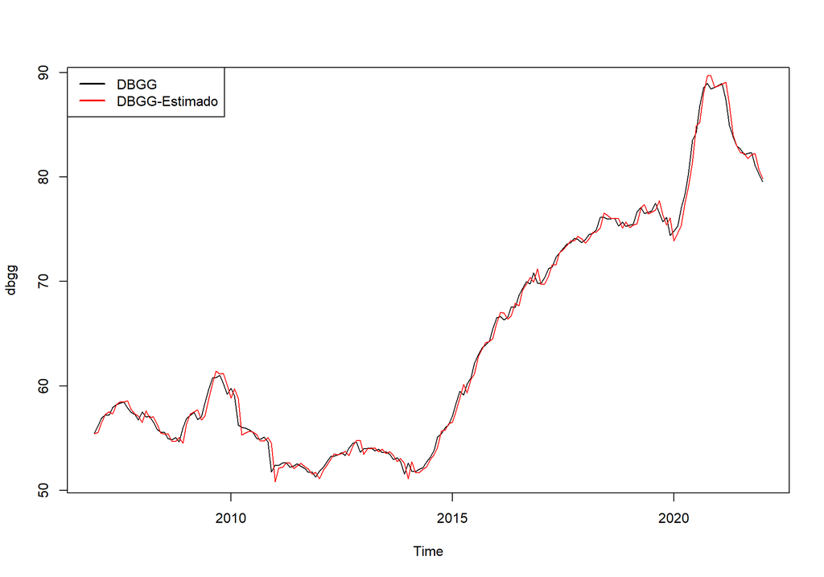

```r
#Visualizacao das duas series - observada e a estimada
plot(dbgg)
lines(fitted(auto.arima), col='red')
legend('topleft', col=c('black','red'), lty=c(1,1), lwd=c(2,2),
       legend=c('DBGG', 'DBGG-Estimado'))
```

Pode-se então, realizar as análises nos resíduos do modelo estimado.

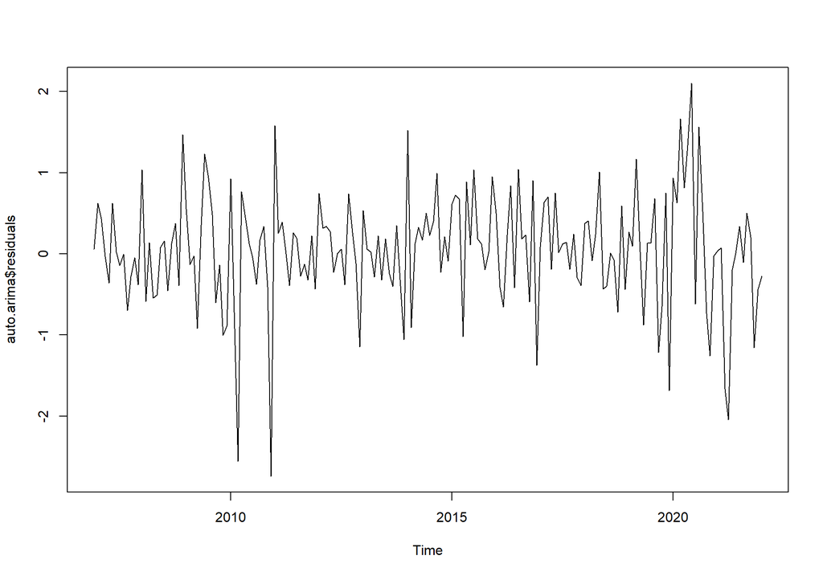

```r
#Analise dos residuos do ARIMA
plot(auto.arima$residuals)
```

```r
#Teste de Ljung Box para autocorrelacao nos residuos
#Hipotese nula do teste eh que os residuos nao sao autocorrelacionados

Box.test(auto.arima$residuals, lag=20,
         type="Ljung-Box", fitdf=length(coef(auto.arima)))
```

```
#
#   Box-Ljung test
#
# data:  auto.arima$residuals
# X-squared = 12, df = 18, p-value = 0.9
```

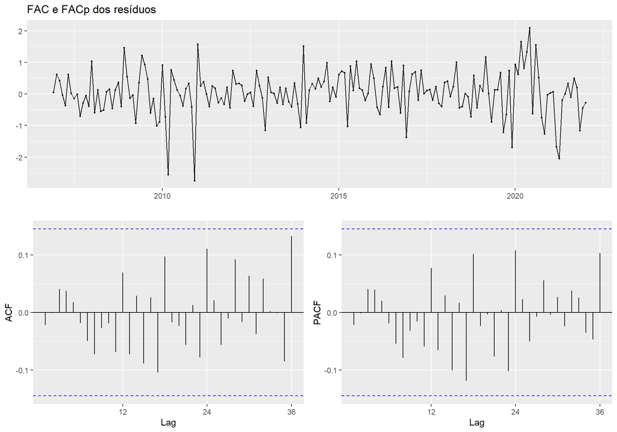

```r
# FAC e FACp dos resíduos
ggtsdisplay(auto.arima$residuals, main='FAC e FACp dos resíduos')
```

```r
#Teste de Normalidade dos residuos
shapiro.test(auto.arima$residuals)
```

```
#
#   Shapiro-Wilk normality test
#
# data:  auto.arima$residuals
# W = 0.97, p-value = 2e-04
```

## 1.6 Uso do modelo para fazer previsão

```r
#E possivel fazer previsoes com os resultados
forecast.arima <- forecast(auto.arima, h=12, level=c(20, 40, 60))
#level é o intervalo de confianca da previsao

forecast.arima
```

```
#          Point Forecast Lo 20 Hi 20 Lo 40 Hi 40 Lo 60 Hi 60
# Feb 2022          79.11 78.93 79.29 78.73 79.48 78.50 79.71
# Mar 2022          78.75 78.45 79.04 78.13 79.36 77.76 79.74
# Apr 2022          78.46 78.05 78.86 77.61 79.30 77.10 79.81
# May 2022          78.22 77.70 78.74 77.15 79.29 76.50 79.94
# Jun 2022          78.03 77.41 78.65 76.75 79.32 75.97 80.10
# Jul 2022          77.88 77.16 78.60 76.39 79.38 75.48 80.28
# Aug 2022          77.76 76.94 78.58 76.07 79.46 75.04 80.48
# Sep 2022          77.66 76.75 78.57 75.78 79.55 74.64 80.69
# Oct 2022          77.58 76.58 78.58 75.51 79.66 74.26 80.91
# Nov 2022          77.52 76.43 78.61 75.27 79.77 73.91 81.13
# Dec 2022          77.47 76.30 78.64 75.05 79.89 73.59 81.35
# Jan 2023          77.43 76.18 78.68 74.85 80.01 73.29 81.57
```

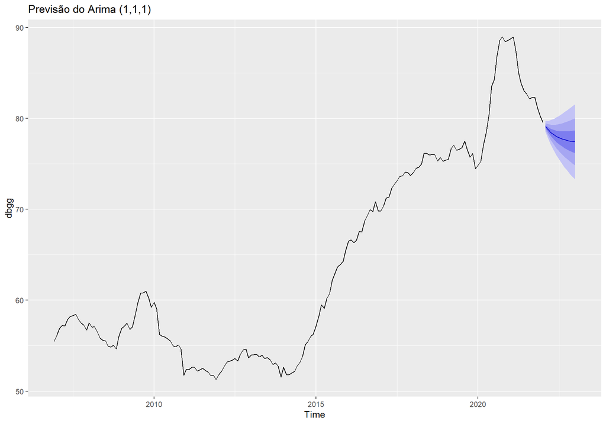

```r
#Grafico da previsao
autoplot(forecast.arima)+
  ggtitle('Previsão do Arima (1,1,1)')
```

```r
#Avaliacao da Previsao
end(dbgg)
```

```
# [1] 2022    1
```

```r
fim <- c(2021,7)
amostra <- window(dbgg, end=fim)
observado <- window(dbgg, start=fim+c(0,1))

#Reestimacao do modelo
arima2 <- Arima(amostra, order=c(1,1,1))
coeftest(arima2)
```

```
#
# z test of coefficients:
#
#     Estimate Std. Error z value Pr(>|z|)
# ar1   0.7993     0.0803    9.95   <2e-16 ***
# ma1  -0.4973     0.1090   -4.56    5e-06 ***
# ---
# Signif. codes:  0 '***' 0.001 '**' 0.01 '*' 0.05 '.' 0.1 ' ' 1
```

```r
summary(arima2)
```

```
# Series: amostra
# ARIMA(1,1,1)
#
# Coefficients:
#         ar1     ma1
#       0.799  -0.497
# s.e.  0.080   0.109
#
# sigma^2 = 0.519:  log likelihood = -190.1
# AIC=386.1   AICc=386.2   BIC=395.6
#
# Training set error measures:
#                   ME   RMSE    MAE     MPE   MAPE   MASE     ACF1
# Training set 0.05595 0.7142 0.5218 0.08486 0.8247 0.1411 -0.02759
```

```r
#previsao com o novo modelo
forecast.arima2 <- forecast(arima2, h=length(observado), level=20)$mean

#Comparação do observado com o estimado
previsao <- tibble(forecast.arima2,observado)
data2 <- c("Agosto/2021","Setembro/2021", "Outubro/2021", "Novembro/2021",
           "Dezembro/2021", "Janeiro/2022")
previsao <- tibble(data2, previsao)

kable(previsao, align='ccc', col.names = c("Data Previsão",
                                           "Previsão com o Modelo Estimado",
                                           "Valores Observados")) %>%
  kable_styling(full_width=TRUE, position = "center")
```

| Data Previsão | Previsão com o Modelo Estimado | Valores Observados |
| --- | --- | --- |
| Agosto/2021 | 82.28 | 82.16 |
| Setembro/2021 | 81.94 | 82.29 |
| Outubro/2021 | 81.67 | 82.34 |
| Novembro/2021 | 81.46 | 81.13 |
| Dezembro/2021 | 81.28 | 80.29 |
| Janeiro/2022 | 81.15 | 79.56 |